# Model 2

## Model definition:

### States

|  | $A$ | $NC$ | $CS$ |
| --- | --- | --- | --- |
| TB-related symptoms | No | Yes | Yes |
| Care-seeking intentions | No | No | Yes |
| TB-related mortality | No | Yes | Yes |
| Sputum smear microscopy | Usually low precision | Positive / Negative | Positive / Negative |

- $A$: Asymptomatic TB
- $NC$: Symptomatic TB without care-seeking
- $CS$: Symptomatic TB with care-seeking intentions

### Dynamics

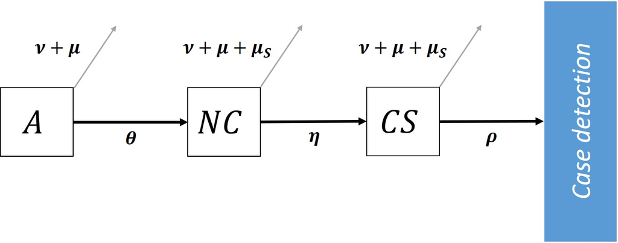

Subject to a **Steady-declining solution** where the annual decline rates: prevalence = incidence = notification = $\phi$

## Empirical model

### Prevalence

We related the prevalence, $Prev_A$, $Prev_{NC}$ and $Prev_{CS}$, to prevalence survey data with the $Binomial$ distribution, where

$$\begin{array}{rl}
Prev_A &= \frac{(\gamma_{NC} + \eta - \phi) / \theta}{(\gamma_{NC} + \eta - \phi) / \theta + 1 + \eta / (\gamma_{CS} + \rho - \phi)} \times Prev \\
Prev_{NC} &= \frac{1}{(\gamma_{NC} + \eta - \phi) / \theta + 1 + \eta / (\gamma_{CS} + \rho - \phi)} \times Prev \\
Prev_{CS} &= \frac{\eta / (\gamma_{CS} + \rho - \phi)}{(\gamma_{NC} + \eta - \phi) / \theta + 1 + \eta / (\gamma_{CS} + \rho - \phi)} \times Prev
\end{array}$$

- $Prev$: the prevalence of all active TB.

### Notification

We related the time-series of case notification rates, $CNR_{CS, t}$, to case-notification and demographic data with the $Poisson$ distribution, where

$$CNR_{CS, t} = \rho Prev_{CS} \times e^{-\phi (t - t0)}$$

- $t$: year
- $t0$: the year with the prevalence survey

### Prior distribution

$$\begin{array}{rl}
\theta & \sim invGamma(1, 1)\\
\eta & \sim invGamma(1, 1)\\
\rho & \sim invGamma(1, 1)\\
\nu & \sim U(0.1, 0.3)\\
\phi & \sim U(-0.2, 0.2)\\
Prev & \sim U(0, 1)
\end{array}$$

The model fitting were implemented `R` with `rstan`.

#### Notations

- $\theta$: Symptom onset rate
- $\eta$: Presence rate of care-seeking intentions
- $\rho$: Care-seeking rate
- $\nu$: Self-cure rate
- $\mu$: Background death rate
- $\mu_{NC}$: Untreated death rate of state $NC$
- $\mu_{CS}$: Untreated death rate of state $CS$
- $\phi$: Annual decline rate for incidence/prevalence/notification
- $\gamma_A = \nu + \mu$: Dropout rate of $A$ (self-cure + death)
- $\gamma_{NC} = \nu + \mu + \mu_{NC}$: Dropout rate of $NC$ (self-cure + death)
- $\gamma_{CS} = \nu + \mu + \mu_{CS}$: Dropout rate of $CS$ (self-cure + death)